# Tugas Pertemuan 6 dan 7

Yasmin Azimah

2023-10-05

## Packages

```r
library(ggplot2)
library(tsibble)
library(tseries)
library(MASS)
library(forecast)
library(TSA)
library(TTR)
library(aTSA)
library(graphics)
```

## Input Data

```r
#Input data
data <- rio::import("https://raw.githubusercontent.com/yasminazimah/MPDW/main/data/Data1.csv")
data <- data$Jumlah_Kematian
data.ts <- ts(data)
```

## Eksplorasi Data

### Plot Data Penuh

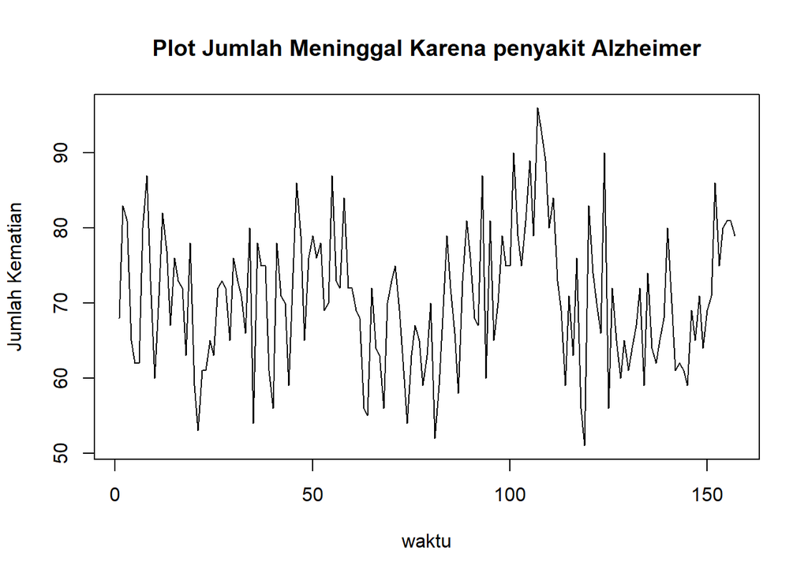

```r
plot.ts(data.ts, xlab="waktu", ylab="Jumlah Kematian", main="Plot Jumlah Meninggal Karena penyakit Alzheimer")
```

### Plot Data Latih

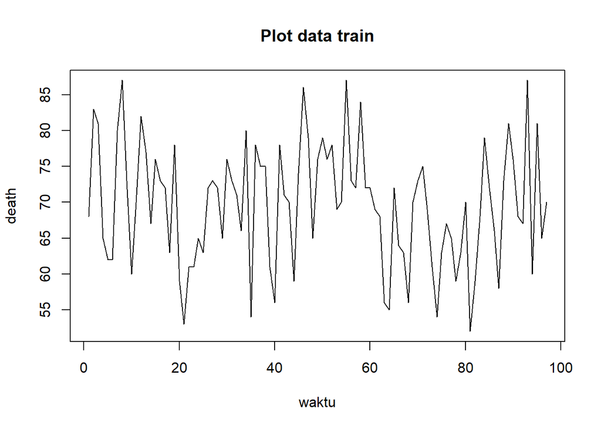

```r
data.train<-data[1:97]
train.ts<-ts(data.train)
plot.ts(train.ts, lty=1, xlab="waktu", ylab="death", main="Plot data train")
```

### Plot Data Uji

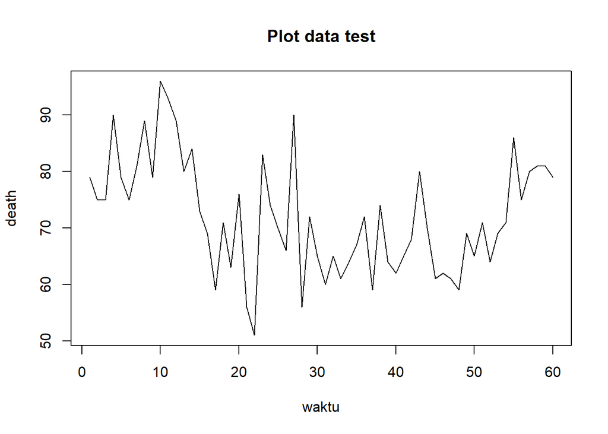

```r
data.test<-data[98:157]
test.ts<-ts(data.test)
plot.ts(test.ts, lty=1, xlab="waktu", ylab="death", main="Plot data test")
```

## Uji Stasioneritas Data ### Plot ACF

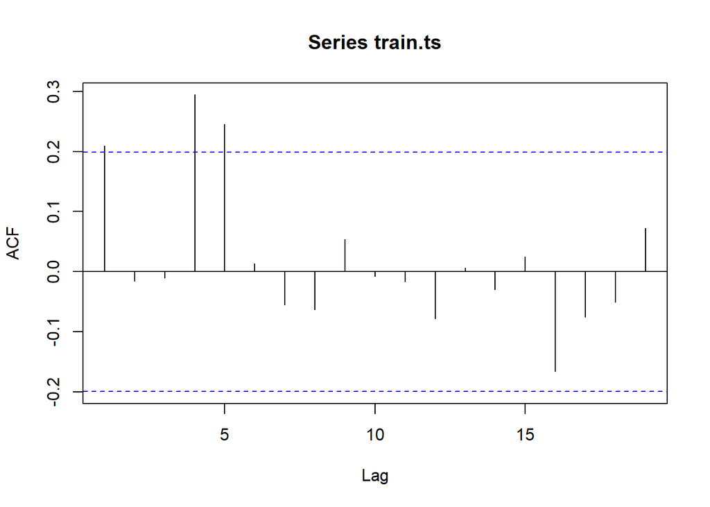

```r
acf(train.ts)
```

```r
tseries::adf.test(train.ts)
```

```
##
##  Augmented Dickey-Fuller Test
##
## data:  train.ts
## Dickey-Fuller = -2.6579, Lag order = 4, p-value = 0.3045
## alternative hypothesis: stationary
```

$H_0$ : Data tidak stasioner dalam rataan

$H_1$ : Data stasioner dalam rataan

Berdasarkan uji ADF tersebut, didapat *p-value* sebesar 0.3045 yang lebih besar dari taraf nyata 5% sehingga tak tolak $H_0$ dan menandakan bahwa data tidak stasioner dalam rataan. Hal ini tidak sesuai dengan hasil eksplorasi menggunakan plot time series dan plot ACF, sehingga ketidakstasioneran model kedepannya harus ditangani

## Plot Box-Cox

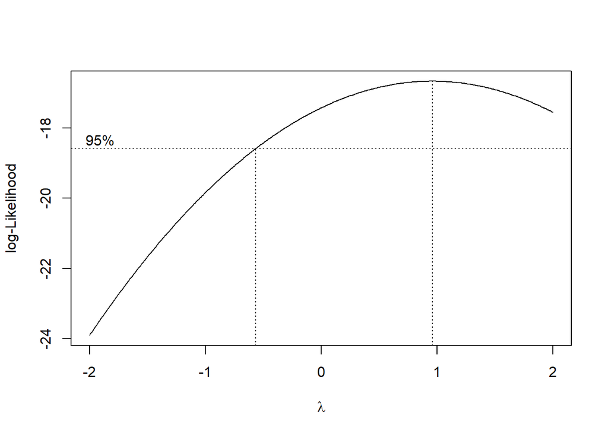

```r
index <- seq(1:97)
bc = boxcox(train.ts~index, lambda = seq(-2,2,by=0.01))
```

```r
#Nilai Rounded Lambda
lambda <- bc$x[which.max(bc$y)]
lambda
```

```
## [1] 0.96
```

```r
#SK
bc$x[bc$y > max(bc$y) - 1/2 * qchisq(.95,1)]
```

```
##   [1] -0.56 -0.55 -0.54 -0.53 -0.52 -0.51 -0.50 -0.49 -0.48 -0.47 -0.46 -0.45
##  [13] -0.44 -0.43 -0.42 -0.41 -0.40 -0.39 -0.38 -0.37 -0.36 -0.35 -0.34 -0.33
##  [25] -0.32 -0.31 -0.30 -0.29 -0.28 -0.27 -0.26 -0.25 -0.24 -0.23 -0.22 -0.21
##  [37] -0.20 -0.19 -0.18 -0.17 -0.16 -0.15 -0.14 -0.13 -0.12 -0.11 -0.10 -0.09
##  [49] -0.08 -0.07 -0.06 -0.05 -0.04 -0.03 -0.02 -0.01  0.00  0.01  0.02  0.03
##  [61]  0.04  0.05  0.06  0.07  0.08  0.09  0.10  0.11  0.12  0.13  0.14  0.15
##  [73]  0.16  0.17  0.18  0.19  0.20  0.21  0.22  0.23  0.24  0.25  0.26  0.27
##  [85]  0.28  0.29  0.30  0.31  0.32  0.33  0.34  0.35  0.36  0.37  0.38  0.39
##  [97]  0.40  0.41  0.42  0.43  0.44  0.45  0.46  0.47  0.48  0.49  0.50  0.51
## [109]  0.52  0.53  0.54  0.55  0.56  0.57  0.58  0.59  0.60  0.61  0.62  0.63
## [121]  0.64  0.65  0.66  0.67  0.68  0.69  0.70  0.71  0.72  0.73  0.74  0.75
## [133]  0.76  0.77  0.78  0.79  0.80  0.81  0.82  0.83  0.84  0.85  0.86  0.87
## [145]  0.88  0.89  0.90  0.91  0.92  0.93  0.94  0.95  0.96  0.97  0.98  0.99
## [157]  1.00  1.01  1.02  1.03  1.04  1.05  1.06  1.07  1.08  1.09  1.10  1.11
## [169]  1.12  1.13  1.14  1.15  1.16  1.17  1.18  1.19  1.20  1.21  1.22  1.23
## [181]  1.24  1.25  1.26  1.27  1.28  1.29  1.30  1.31  1.32  1.33  1.34  1.35
## [193]  1.36  1.37  1.38  1.39  1.40  1.41  1.42  1.43  1.44  1.45  1.46  1.47
## [205]  1.48  1.49  1.50  1.51  1.52  1.53  1.54  1.55  1.56  1.57  1.58  1.59
## [217]  1.60  1.61  1.62  1.63  1.64  1.65  1.66  1.67  1.68  1.69  1.70  1.71
## [229]  1.72  1.73  1.74  1.75  1.76  1.77  1.78  1.79  1.80  1.81  1.82  1.83
## [241]  1.84  1.85  1.86  1.87  1.88  1.89  1.90  1.91  1.92  1.93  1.94  1.95
## [253]  1.96  1.97  1.98  1.99  2.00
```

## Penanganan Ketidakstasioneran Data

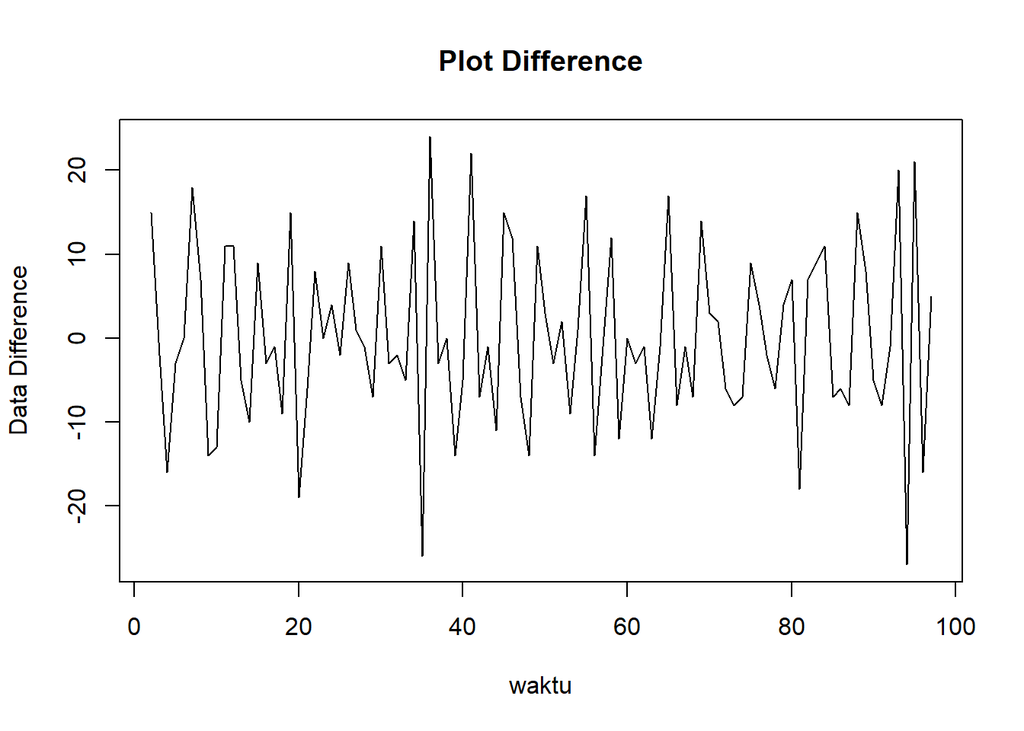

```r
train.diff<-diff(train.ts,differences = 1)
plot.ts(train.diff, lty=1, xlab="waktu", ylab="Data Difference", main="Plot Difference")
```

Berdasarkan plot data deret waktu, terlihat bahwa data sudah stasioner dalam rataan ditandai dengan data bergerak pada nilai tengah tertentu (tidak terdapat trend ataupun musiman pada data)

### Plot ACF

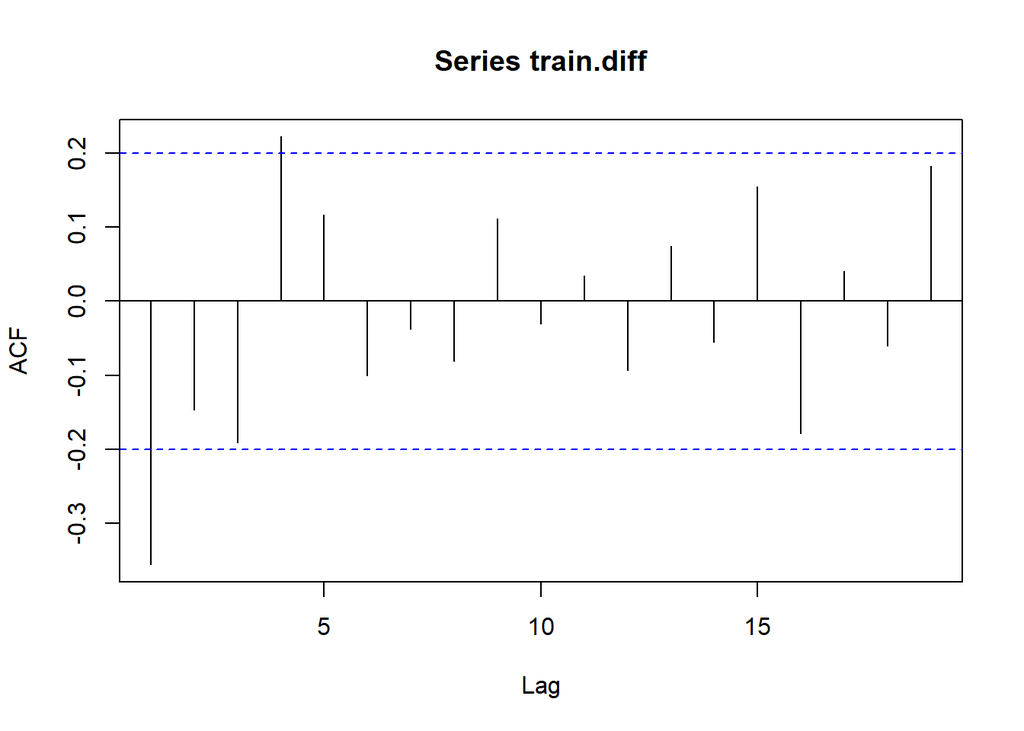

```r
acf(train.diff)
```

erdasarkan plot tersebut, terlihat bahwa plot ACF cuts off pada lag ke 1. Hal ini menandakan data sudah stasioner dalam rataan dan ketidakstasioneran data telah berhasil tertangani.

### Uji ADF

```r
tseries::adf.test(train.diff)
```

```
##
##  Augmented Dickey-Fuller Test
##
## data:  train.diff
## Dickey-Fuller = -6.6775, Lag order = 4, p-value = 0.01
## alternative hypothesis: stationary
```

$H_0$ : Data tidak stasioner dalam rataan

$H_1$ : Data stasioner dalam rataan

Berdasarkan uji ADF tersebut, didapat *p-value* sebesar 0.01 yang lebih kecil dari taraf nyata 5% sehingga tolak $H_0$ atau data stasioner dalam rataan. Hal ini sesuai dengan hasil eksplorasi menggunakan plot time series dan plot ACF, sehingga dalam hal ini ketidakstasioneran data sudah berhasil ditangani dan dapat dilanjutkan ke pemodelan

## Identifikasi Model

### Plot ACF

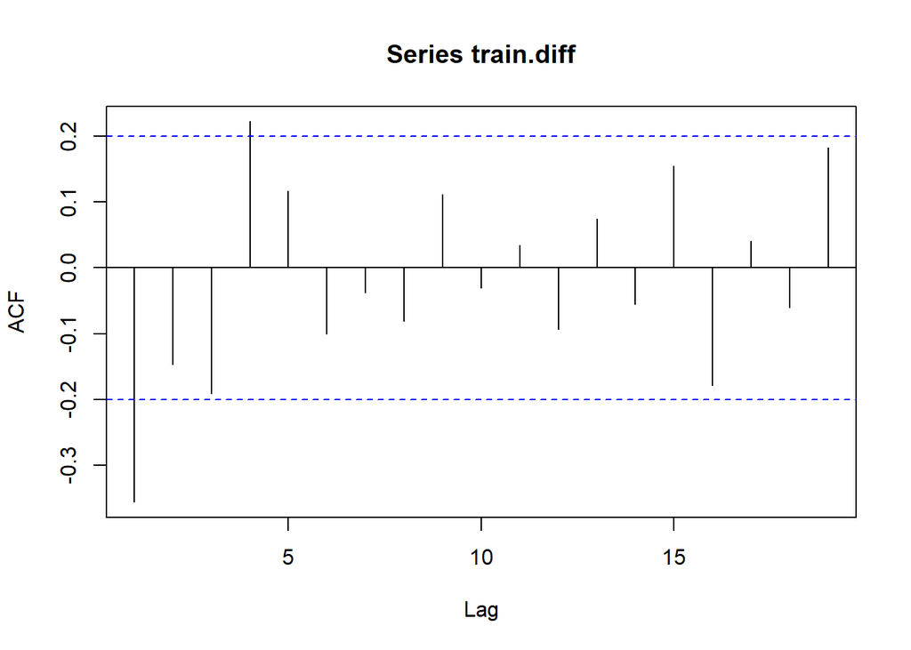

```r
acf(train.diff)
```

Berdasarkan plot tersebut, terlihat bahwa plot ACF cenderung *cuts off* pada lag ke 1, sehingga jika plot PACF dianggap *tails of*, maka model tentatifnya adalah ARIMA(0,1,1).

### Plot PACF

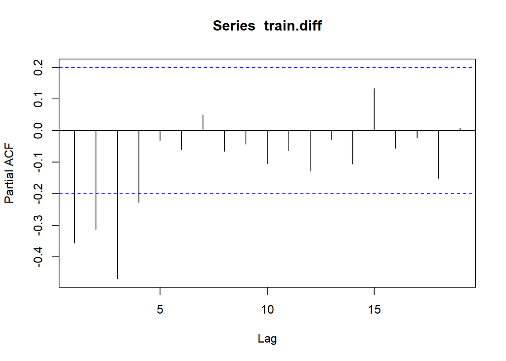

```r
pacf(train.diff)
```

Berdasarkan plot tersebut, terlihat bahwa plot PACF cenderung *cuts off* pada lag ke 4, sehingga jika plot ACF dianggap *tails of*, maka model tentatifnya adalah ARIMA(4,1,0).

Jika baik plot ACF maupun plot PACF keduanya dianggap tails of, maka model yang terbentuk adalah ARIMA(1,1,1)

### Plot EACF

```r
eacf(train.diff)
```

```
## AR/MA
##   0 1 2 3 4 5 6 7 8 9 10 11 12 13
## 0 x o o x o o o o o o o  o  o  o
## 1 x o x o x o o o o o o  o  o  o
## 2 x x x o o o o o o o o  o  o  o
## 3 x o o o o o o o o o o  o  o  o
## 4 o o o o o o o o o o o  o  o  o
## 5 x o o o o o o o o o o  o  o  o
## 6 x o o o o o o o o o o  o  o  o
## 7 x o o x o o o o o o o  o  o  o
```

Identifikasi model menggunakan plot EACF dilakukan dengan melihat ujung segitiga pada pola segitiga nol. Dalam hal ini model tentatif yang terbentuk adalah ARIMA(0,1,2), ARIMA(1,1,3), dan ARIMA(2,1,3)

## Pendugaan Parameter Model Tentatif

### ARIMA(0,1,1)

```r
model1.da=Arima(train.diff, order=c(0,1,1),method="ML")
summary(model1.da) #AIC=727.71
```

```
## Series: train.diff
## ARIMA(0,1,1)
##
## Coefficients:
##           ma1
##       -1.0000
## s.e.   0.0261
##
## sigma^2 = 114.7:  log likelihood = -361.86
## AIC=727.71   AICc=727.84   BIC=732.82
##
## Training set error measures:
##                      ME     RMSE      MAE MPE MAPE      MASE       ACF1
## Training set -0.3227394 10.59973 8.459566 NaN  Inf 0.6249291 -0.3362742
```

```r
lmtest::coeftest(model1.da) #seluruh parameter signifikan
```

```
##
## z test of coefficients:
##
##      Estimate Std. Error z value  Pr(>|z|)
## ma1 -0.999995   0.026062  -38.37 < 2.2e-16 ***
## ---
## Signif. codes:  0 '***' 0.001 '**' 0.01 '*' 0.05 '.' 0.1 ' ' 1
```

### ARIMA(4,1,0)

```r
model2.da=Arima(train.diff, order=c(4,1,0),method="ML")
summary(model2.da) #AIC=717.04
```

```
## Series: train.diff
## ARIMA(4,1,0)
##
## Coefficients:
##           ar1      ar2      ar3      ar4
##       -1.2416  -1.1643  -1.0092  -0.4987
## s.e.   0.0910   0.1191   0.1155   0.0952
##
## sigma^2 = 101.3:  log likelihood = -353.52
## AIC=717.04   AICc=717.72   BIC=729.81
##
## Training set error measures:
##                      ME     RMSE      MAE MPE MAPE      MASE      ACF1
## Training set -0.2436677 9.800654 7.847356 NaN  Inf 0.5797036 -0.124427
```

```r
lmtest::coeftest(model2.da) #seluruh parameter signifikan
```

```
##
## z test of coefficients:
##
##      Estimate Std. Error  z value  Pr(>|z|)
## ar1 -1.241630   0.091042 -13.6380 < 2.2e-16 ***
## ar2 -1.164297   0.119069  -9.7784 < 2.2e-16 ***
## ar3 -1.009242   0.115480  -8.7395 < 2.2e-16 ***
## ar4 -0.498701   0.095225  -5.2371 1.631e-07 ***
## ---
## Signif. codes:  0 '***' 0.001 '**' 0.01 '*' 0.05 '.' 0.1 ' ' 1
```

### ARIMA(1,1,1)

```r
model3.da=Arima(train.diff, order=c(1,1,1),method="ML")
summary(model3.da) #AIC=717.3
```

```
## Series: train.diff
## ARIMA(1,1,1)
##
## Coefficients:
##           ar1      ma1
##       -0.3533  -1.0000
## s.e.   0.0965   0.0264
##
## sigma^2 = 101:  log likelihood = -355.65
## AIC=717.3   AICc=717.56   BIC=724.96
##
## Training set error measures:
##                      ME     RMSE      MAE MPE MAPE      MASE        ACF1
## Training set -0.1973794 9.890973 8.158497 NaN  Inf 0.6026884 -0.09070028
```

```r
lmtest::coeftest(model3.da) #seluruh parameter signifikan
```

```
##
## z test of coefficients:
##
##      Estimate Std. Error  z value  Pr(>|z|)
## ar1 -0.353306   0.096508  -3.6609 0.0002513 ***
## ma1 -1.000000   0.026439 -37.8229 < 2.2e-16 ***
## ---
## Signif. codes:  0 '***' 0.001 '**' 0.01 '*' 0.05 '.' 0.1 ' ' 1
```

### ARIMA(0,1,2)

```r
model4.da=Arima(train.diff, order=c(0,1,2),method="ML")
summary(model4.da) #AIC=691.88
```

```
## Series: train.diff
## ARIMA(0,1,2)
##
## Coefficients:
##           ma1     ma2
##       -1.8206  0.8206
## s.e.   0.0820  0.0788
##
## sigma^2 = 74.31:  log likelihood = -342.94
## AIC=691.88   AICc=692.14   BIC=699.54
##
## Training set error measures:
##                     ME     RMSE      MAE MPE MAPE      MASE       ACF1
## Training set 0.2996681 8.484584 6.994763 NaN  Inf 0.5167204 0.09648535
```

```r
lmtest::coeftest(model4.da) #seluruh parameter signifikan
```

```
##
## z test of coefficients:
##
##      Estimate Std. Error z value  Pr(>|z|)
## ma1 -1.820627   0.082040 -22.192 < 2.2e-16 ***
## ma2  0.820634   0.078752  10.421 < 2.2e-16 ***
## ---
## Signif. codes:  0 '***' 0.001 '**' 0.01 '*' 0.05 '.' 0.1 ' ' 1
```

### ARIMA(1,1,3)

```r
model5.da=Arima(train.diff, order=c(1,1,3),method="ML")
summary(model5.da) #AIC=694.3
```

```
## Series: train.diff
## ARIMA(1,1,3)
##
## Coefficients:
##           ar1      ma1     ma2     ma3
##       -0.1405  -1.5803  0.3347  0.2457
## s.e.   0.3924   0.3813  0.6747  0.3021
##
## sigma^2 = 74.42:  log likelihood = -342.15
## AIC=694.3   AICc=694.97   BIC=707.07
##
## Training set error measures:
##                    ME     RMSE      MAE MPE MAPE     MASE        ACF1
## Training set 0.267306 8.399038 6.842022 NaN  Inf 0.505437 0.002150439
```

```r
lmtest::coeftest(model5.da) #tidak seluruh parameter signifikan
```

```
##
## z test of coefficients:
##
##     Estimate Std. Error z value  Pr(>|z|)
## ar1 -0.14047    0.39242 -0.3579    0.7204
## ma1 -1.58031    0.38126 -4.1450 3.398e-05 ***
## ma2  0.33465    0.67471  0.4960    0.6199
## ma3  0.24568    0.30213  0.8132    0.4161
## ---
## Signif. codes:  0 '***' 0.001 '**' 0.01 '*' 0.05 '.' 0.1 ' ' 1
```

### ARIMA(2,1,3)

```r
model6.da=Arima(train.diff, order=c(2,1,3),method="ML")
summary(model6.da) #AIC=691.55
```

```
## Series: train.diff
## ARIMA(2,1,3)
##
## Coefficients:
##          ar1      ar2      ma1     ma2      ma3
##       0.4378  -0.4661  -2.1117  1.6167  -0.5050
## s.e.  0.1987   0.1758   0.1686  0.3774   0.2353
##
## sigma^2 = 72.93:  log likelihood = -339.78
## AIC=691.55   AICc=692.51   BIC=706.88
##
## Training set error measures:
##                     ME     RMSE      MAE MPE MAPE      MASE        ACF1
## Training set 0.1209137 8.268668 6.729886 NaN  Inf 0.4971533 -0.05050557
```

```r
lmtest::coeftest(model6.da) #seluruh parameter signifikan
```

```
##
## z test of coefficients:
##
##     Estimate Std. Error  z value  Pr(>|z|)
## ar1  0.43778    0.19868   2.2035  0.027562 *
## ar2 -0.46614    0.17579  -2.6518  0.008007 **
## ma1 -2.11166    0.16856 -12.5275 < 2.2e-16 ***
## ma2  1.61669    0.37744   4.2833 1.841e-05 ***
## ma3 -0.50503    0.23528  -2.1465  0.031832 *
## ---
## Signif. codes:  0 '***' 0.001 '**' 0.01 '*' 0.05 '.' 0.1 ' ' 1
```

Berdasarkan pendugaan parameter di atas, nilai AIC terkecil dimiliki oleh model ARIMA(2,1,3) dan parameter model ARIMA(2,1,3) juga seluruh parameternya signifikan sehingga model yang dipilih adalah model ARIMA(2,1,3).

## Analisis Sisaan

Model terbaik hasil identifikasi kemudian dicek asumsi sisaannya. Sisaan model ARIMA harus memenuhi asumsi normalitas, kebebasan sisaan, dan kehomogenan ragam. Diagnostik model dilakukan secara eksplorasi dan uji formal.

### Eksplorasi Sisaan

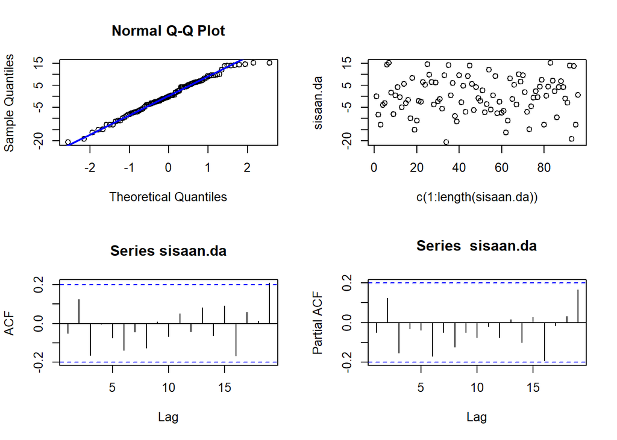

```r
#Eksplorasi
sisaan.da <- model6.da$residuals
par(mfrow=c(2,2))
qqnorm(sisaan.da)
qqline(sisaan.da, col = "blue", lwd = 2)
plot(c(1:length(sisaan.da)),sisaan.da)
acf(sisaan.da)
pacf(sisaan.da)
```

```r
par(mfrow = c(1,1))
```

Berdasarkan plot kuantil-kuantil normal, secara eksplorasi ditunjukkan sisaan menyebar normal ditandai dengan titik titik yang cenderung mengikuti garis $45^{\circ}$. Kemudian dapat dilihat juga lebar pita sisaan yang cenderung sama menandakan bahwa sisaan memiliki ragam yang homogen. Plot ACF dan PACF sisaan ARIMA(2,1,3) juga tidak signifikan pada 20 lag awal yang menandakan saling bebas. Kondisi ini akan diuji lebih lanjut dengan uji formal.

### Uji Formal

```r
#1) Sisaan Menyebar Normal
tseries::jarque.bera.test(sisaan.da)
```

```
##
##  Jarque Bera Test
##
## data:  sisaan.da
## X-squared = 1.4807, df = 2, p-value = 0.4769
```

Selain dengan eksplorasi, asumsi tersebut dapat diuji menggunakan uji formal. Pada tahapan ini uji formal yang digunakan untuk normalitas adalah uji Jarque Bera . Hipotesis pada uji Jarque Bera adalah sebagai berikut.

$H_0$ : Sisaan menyebar normal

$H_1$ : Sisaan tidak menyebar normal

```r
#2) Sisaan saling bebas/tidak ada autokorelasi
Box.test(sisaan.da, type = "Ljung")
```

```
##
##  Box-Ljung test
##
## data:  sisaan.da
## X-squared = 0.25261, df = 1, p-value = 0.6152
```

Selanjutnya akan dilakukan uji formal untuk kebebasan sisaan menggunakan uji Ljung-Box. Hipotesis yang digunakan adalah sebagai berikut.

$H_0$ : Sisaan saling bebas

$H_1$ : Sisaan tidak tidak saling bebas

Berdasarkan uji Ljung-Box tersebut, didapat *p-value* sebesar 0.6152 yang lebih besar dari taraf nyata 5% sehingga tak tolak $H_0$ dan menandakan bahwa sisaan saling bebas. Hal ini sesuai dengan hasil eksplorasi.

```r
#3) Sisaan homogen
Box.test((sisaan.da)^2, type = "Ljung")
```

```
##
##  Box-Ljung test
##
## data:  (sisaan.da)^2
## X-squared = 6.7116, df = 1, p-value = 0.009579
```

Hipotesis yang digunakan untuk uji kehomogenan ragam adalah sebagai berikut.

$H_0$ : Ragam sisaan homogen

$H_1$ : Ragam sisaan tidak homogen

Berdasarkan uji Ljung-Box terhadap sisaan kuadrat tersebut, didapat *p-value* sebesar 0.009579 yang lebih kecil dari taraf nyata 5% sehingga tolak $H_0$ dan menandakan bahwa ragam sisaan tidak homogen.

```r
#4) Nilai tengah sisaan sama dengan nol
t.test(sisaan.da, mu = 0, conf.level = 0.95)
```

```
##
##  One Sample t-test
##
## data:  sisaan.da
## t = 0.14254, df = 95, p-value = 0.887
## alternative hypothesis: true mean is not equal to 0
## 95 percent confidence interval:
##  -1.563089  1.804916
## sample estimates:
## mean of x
## 0.1209137
```

Dengan uji-t, akan dicek apakah nilai tengah sisaan sama dengan nol. Hipotesis yang diujikan sebagai berikut.

$H_0$ : nilai tengah sisaan sama dengan 0

$H_1$ : nilai tengah sisaan tidak sama dengan 0

Berdasarkan uji-ttersebut, didapat *p-value* sebesar 0.887 yang lebih besar dari taraf nyata 5% sehingga tak tolak $H_0$ dan menandakan bahwa nilai tengah sisaan sama dengan nol. Hal ini sama dengan hasil eksplorasi.

## Overfitting

Tahapan selanjutnya adalah *overfitting* dilakukan dengan menaikkan orde AR(p) dan MA(q) dari model ARIMA(2,1,3) untuk melihat apakah terdapat model lain yang lebih baik dari model saat ini. Kandidat model *overfitting* adalah ARIMA(3,1,3) dan ARIMA(2,1,4).

### Model ARIMA(3,1,3)

```r
model.overfit1=Arima(train.diff, order=c(3,1,3),method="ML")
summary(model.overfit1) #688.25
```

```
## Series: train.diff
## ARIMA(3,1,3)
##
## Coefficients:
##           ar1      ar2      ar3      ma1     ma2      ma3
##       -0.1622  -0.4638  -0.3845  -1.5573  0.7644  -0.2071
## s.e.   0.3426   0.1266   0.1302   0.3556  0.6575   0.3237
##
## sigma^2 = 69.37:  log likelihood = -337.13
## AIC=688.25   AICc=689.54   BIC=706.13
##
## Training set error measures:
##                   ME     RMSE      MAE MPE MAPE      MASE        ACF1
## Training set 0.12765 8.019266 6.505201 NaN  Inf 0.4805553 0.005540439
```

```r
lmtest::coeftest(model.overfit1) #3 dari 6 peubah signifikan
```

```
##
## z test of coefficients:
##
##     Estimate Std. Error z value  Pr(>|z|)
## ar1 -0.16220    0.34257 -0.4735 0.6358689
## ar2 -0.46377    0.12660 -3.6634 0.0002489 ***
## ar3 -0.38454    0.13020 -2.9535 0.0031423 **
## ma1 -1.55725    0.35555 -4.3798 1.188e-05 ***
## ma2  0.76438    0.65755  1.1625 0.2450436
## ma3 -0.20711    0.32370 -0.6398 0.5222891
## ---
## Signif. codes:  0 '***' 0.001 '**' 0.01 '*' 0.05 '.' 0.1 ' ' 1
```

### Model ARIMA(2,1,4)

```r
model.overfit2=Arima(train.diff, order=c(2,1,4),method="ML")
summary(model.overfit2) #694
```

```
## Series: train.diff
## ARIMA(2,1,4)
##
## Coefficients:
##           ar1      ar2      ma1      ma2      ma3     ma4
##       -0.8045  -0.6272  -0.8653  -0.2161  -0.6022  0.6837
## s.e.   0.3012   0.3340   0.2562   0.2420   0.4082  0.2413
##
## sigma^2 = 72.53:  log likelihood = -340
## AIC=694   AICc=695.29   BIC=711.88
##
## Training set error measures:
##                     ME     RMSE      MAE MPE MAPE      MASE        ACF1
## Training set 0.1884853 8.200076 6.590163 NaN  Inf 0.4868317 -0.02993643
```

```r
lmtest::coeftest(model.overfit2) #3 dari 6 peubah signifikan
```

```
##
## z test of coefficients:
##
##     Estimate Std. Error z value  Pr(>|z|)
## ar1 -0.80447    0.30116 -2.6712 0.0075572 **
## ar2 -0.62721    0.33402 -1.8778 0.0604149 .
## ma1 -0.86529    0.25617 -3.3778 0.0007306 ***
## ma2 -0.21614    0.24201 -0.8931 0.3718007
## ma3 -0.60222    0.40816 -1.4755 0.1400891
## ma4  0.68366    0.24129  2.8333 0.0046072 **
## ---
## Signif. codes:  0 '***' 0.001 '**' 0.01 '*' 0.05 '.' 0.1 ' ' 1
```

```r
#model yang dipilih adalah model awal, yaitu ARIMA(2,1,3)
```

## Peramalan

Peramalan dilakukan menggunakan fungsi `forecast()` . Contoh peramalan berikut ini dilakukan untuk 30 periode ke depan.

```r
#---FORECAST---#
ramalan.da <- forecast::forecast(model6.da, h = 30)
ramalan.da
```

```
##     Point Forecast      Lo 80    Hi 80     Lo 95    Hi 95
##  98     2.39620074  -8.605774 13.39818 -14.42987 19.22227
##  99    -0.95549045 -14.157854 12.24687 -21.14676 19.23578
## 100    -1.56545570 -15.057335 11.92642 -22.19950 19.06859
## 101    -0.27012099 -13.945119 13.40488 -21.18423 20.64398
## 102     0.58128650 -13.288702 14.45127 -20.63103 21.79360
## 103     0.35020755 -13.519685 14.22010 -20.86196 21.56238
## 104    -0.14783273 -14.055530 13.75986 -21.41782 21.12215
## 105    -0.25815080 -14.171923 13.65562 -21.53743 21.02113
## 106    -0.07428824 -13.992226 13.84365 -21.35994 21.21136
## 107     0.05762780 -13.865655 13.98091 -21.23619 21.35145
## 108     0.02967223 -13.893646 13.95299 -21.26421 21.32355
## 109    -0.04405800 -13.967746 13.87963 -21.33850 21.25038
## 110    -0.06330461 -13.986954 13.86034 -21.35769 21.23108
## 111    -0.03736162 -13.961199 13.88648 -21.33203 21.25731
```

[output cut: 16 more lines]

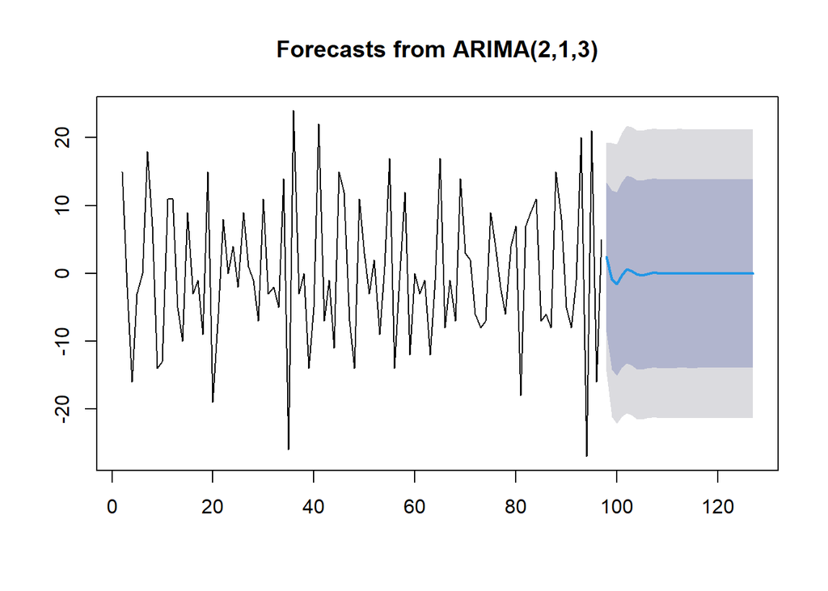

```r
data.ramalan.da <- ramalan.da$mean
plot(ramalan.da)
```

Berdasarkan hasil plot ramalan di atas, dapat dilihat bahwa ramalan ARIMA(2,1,3) cenderung stabil hingga akhir periode. Selanjutnya, dapat dicari nilai akurasi antara hasil ramalan dengan data uji sebagai berikut.

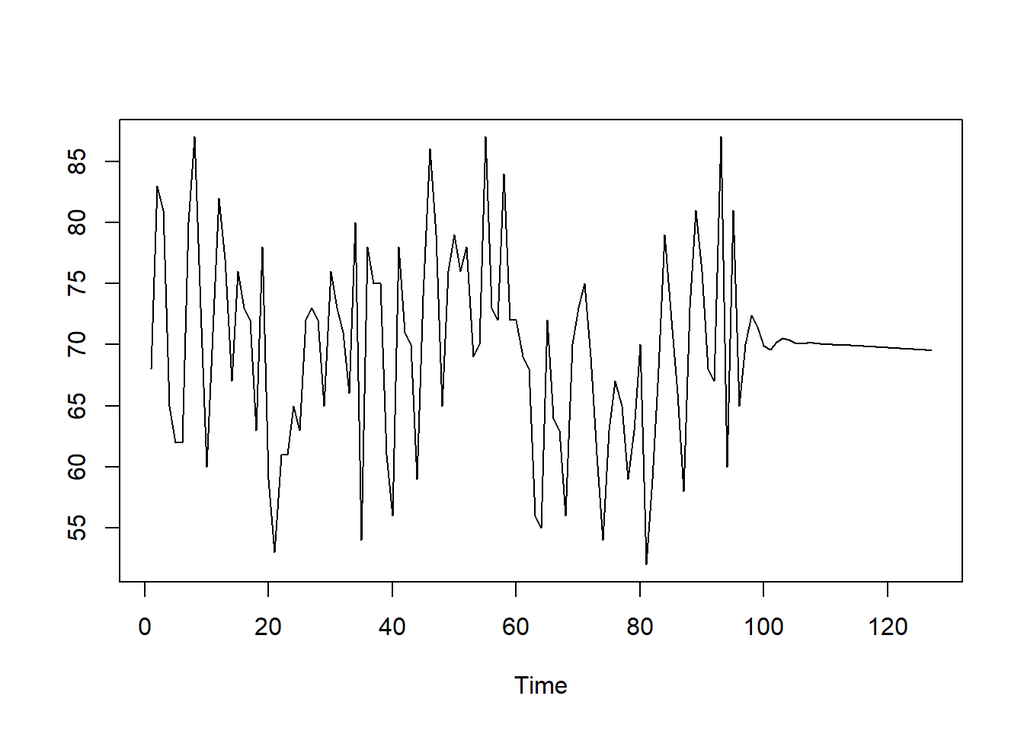

```r
pt_1 <- train.ts[97] #nilai akhir data latih
hasil.forc.Diff <- data.ramalan.da
hasil <- diffinv(hasil.forc.Diff, differences = 1) + pt_1

#has.1 sama hasilnta dengan: cumsum(c(pt_1,hasil.forc.Diff))
ts.plot(train.ts,hasil)
```

```r
perbandingan.da<-matrix(data=c(head(test.ts, n=30), hasil[-1]),
                     nrow = 30, ncol = 2)
colnames(perbandingan.da)<-c("Aktual","Hasil Forecast")
perbandingan.da
```

```
##       Aktual Hasil Forecast
##  [1,]     79       72.39620
##  [2,]     75       71.44071
##  [3,]     75       69.87525
##  [4,]     90       69.60513
##  [5,]     79       70.18642
##  [6,]     75       70.53663
##  [7,]     81       70.38879
##  [8,]     89       70.13064
##  [9,]     79       70.05636
## [10,]     96       70.11398
## [11,]     93       70.14366
## [12,]     89       70.09960
## [13,]     80       70.03629
## [14,]     84       69.99893
```

[output cut: 16 more lines]

```r
accuracy(ts(hasil[-1]), head(test.ts, n=30))
```

```
##                ME     RMSE      MAE      MPE     MAPE      ACF1 Theil's U
## Test set 5.224895 12.35961 10.10215 4.669237 13.27829 0.2932431 0.8440023
```